# Population-wise genetic variation

#### Aim: Interpreting population distribution of genetic variation.

### Geography of Genetic Variants

**Resource:** The [**Geography of Genetic Variants (GGV)**](https://popgen.uchicago.edu/ggv/?data=%221000genomes) browser plots allele frequencies from the [**1000 Genomes**](https://mccoy-lab.github.io/hgv_modules/the-1000-genomes-project.html) dataset.

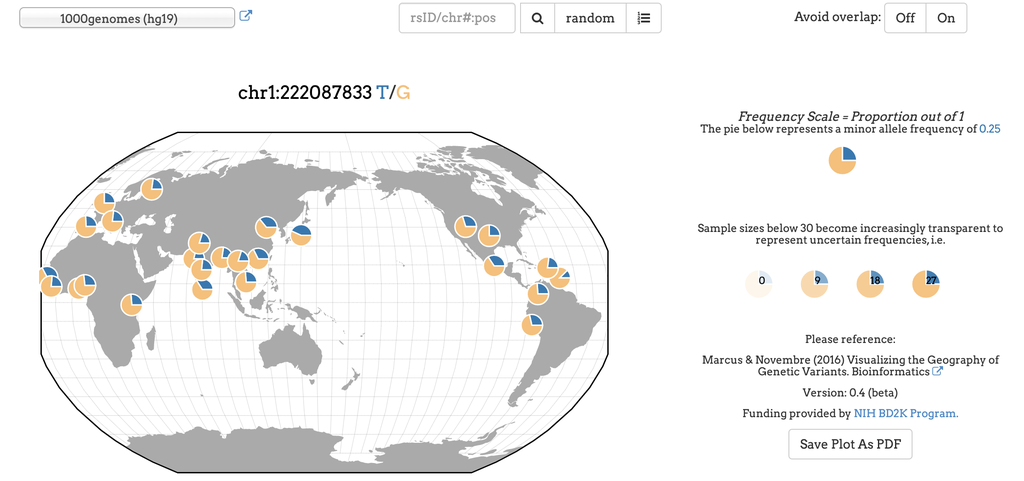

**Fig. 2.** GGV visualization of the allele frequencies for a SNP at `chr1:222087833`.

### Genotype data

Using genotype data summarized from the [1000 Genomes Project](https://mccoy-lab.github.io/hgv_modules/the-1000-genomes-project.html) in two files:

- `all_variants.txt.gz`, which contains a random selection of variants on chr21
- `common_variants.txt`, which contains only those variants in `all_variants` that are common across populations

```r
library(tidyverse)

# all variants
all <- read.table("all_variants.txt.gz")

# only common variants
common <- read.table("common_variants.txt.gz")

metadata <- read.table("integrated_call_samples.txt",
                       header = TRUE)
```

The **index** of the dataframe is the variant ID. * The first column (`AF`) contains the variant’s **allele frequency (AF)** dataset-wide. * The next five columns contain the variant’s AF in each of the five 1000 Genomes superpopulations. * The rest of the columns provide variant **genotypes** for each individual in 1000 Genomes, where: * `0` is homozygous reference * `1` is heterozygous * `2` is homozygous for variant

### The allele frequency spectrum

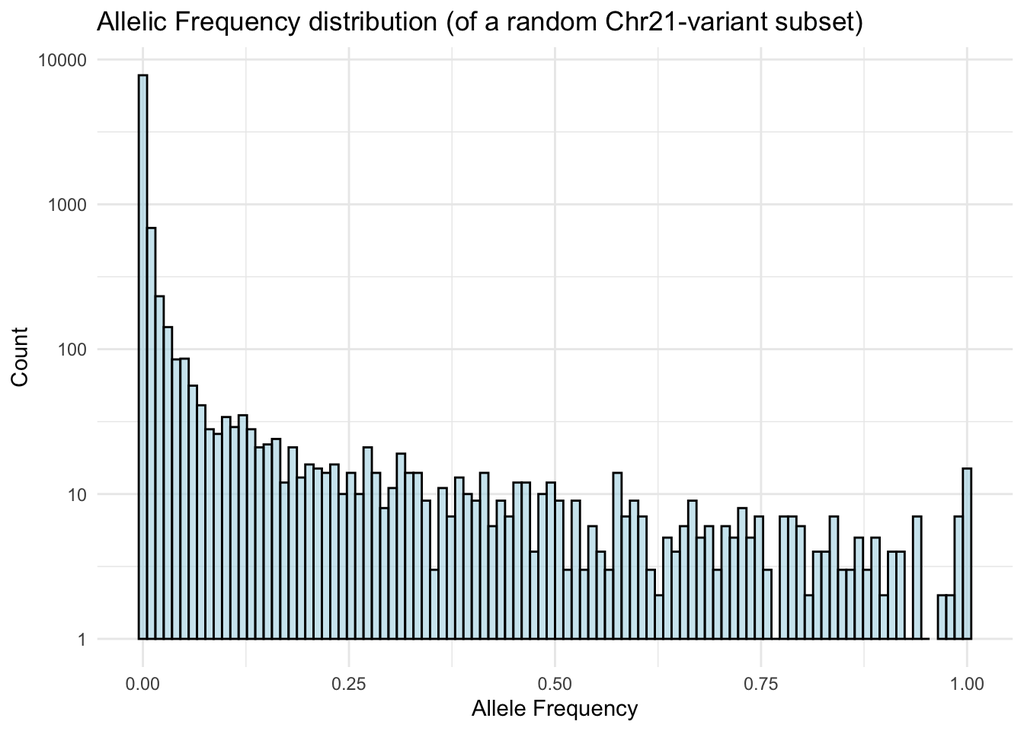

```r
ggplot() +
  geom_histogram(data = all, mapping = aes(x = AF),
                 bins = 100, fill = "lightblue", color = "black", alpha = 0.6) +
  scale_y_continuous(trans="log10") +
  labs(x="Allele Frequency", y="Count") +
  ggtitle("Allelic Frequency distribution (of a random Chr21-variant subset)")
```

The allele frequencies range with an **exponential decay** from zero, indicating that the majority of variants are rare. This distribution is exacerbated in human populations, where recent population expansions have resulted in an excess of rare variation.

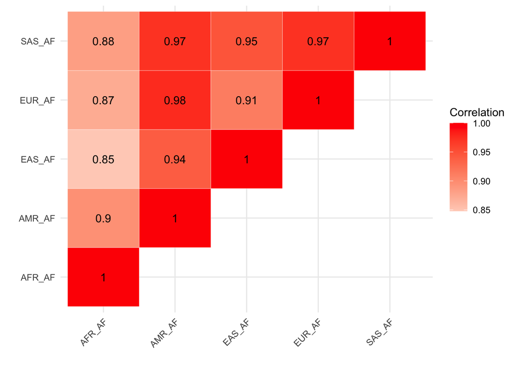

```r
populations = c("AFR_AF", "AMR_AF", "EAS_AF", "EUR_AF", "SAS_AF")

AF_cors <- data.frame()
for (i in 1:(length(populations))) {
  for (j in i:length(populations)) {
    I <- populations[i]
    J <- populations[j]

    r <- cor(all[[I]], all[[J]])

    AF_cors <- rbind(AF_cors, data.frame(r = r, i = I, j = J))
  }
}

rm(i, j, I, J)

ggplot(AF_cors, aes(x = i, y = j, fill = r)) +
  geom_tile(color = "white") +
  geom_text(aes(label = round(r, 2)), color = "black") +
  scale_fill_gradient2(low = "white", high = "red", midpoint = 0.8) +
  theme_minimal() +
  labs(x = "", y = "", fill = "Correlation") +
  theme(axis.text.x = element_text(angle = 45, hjust = 1))
```

```r
# SAS = South Asian
# EUR = European
# EAS = East Asian
# AMR = Admixed American
# AFR = African
```

### PCA

```r
# subset to just genotype columns
gt_matrix_T <- common[, 7:2510] %>%
  as.matrix %>% t

pca <- prcomp(gt_matrix_T)
```

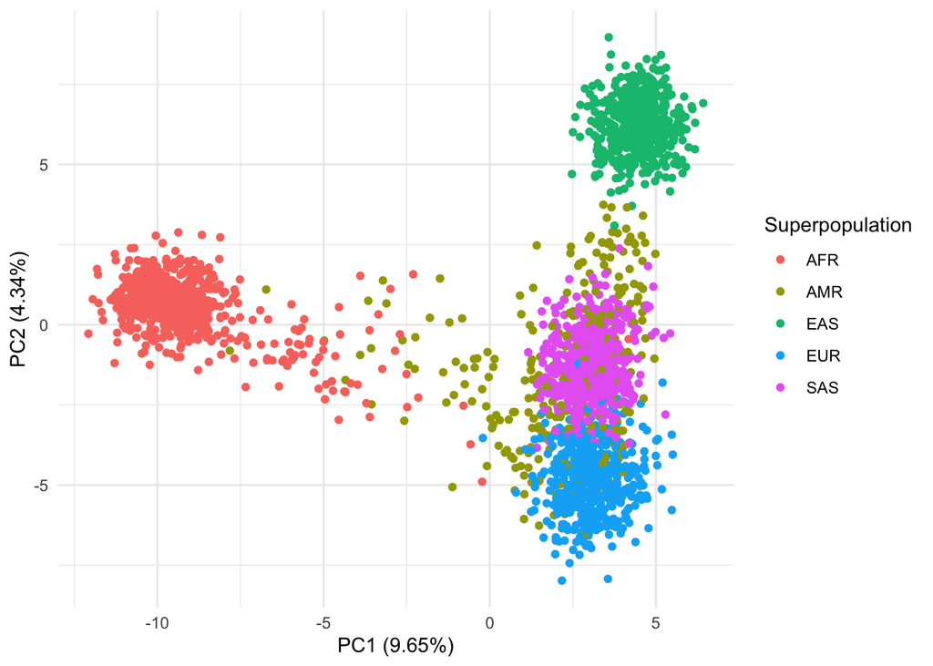

```r
x <- pca$x

pca_results <- data.frame(sample = rownames(x),
                          PC1 = x[, 1], # PC1 values
                          PC2 = x[, 2], # PC2 values
                          PC3 = x[, 3]) # PC3 values

pca_results <- merge(pca_results, metadata,
                     by.x = "sample", by.y = "sample")

sd <- pca$sdev
var_explained <- sd^2 / sum(sd^2)

ggplot(data = pca_results,
       aes(x = PC1, y = PC2, color = superpop)) +
  geom_point() +
  xlab("PC1 (9.65%)") +
  ylab("PC2 (4.34%)") +
  labs(color = "Superpopulation")
```

PC1 separates out the African populations from other populations. This is in line with our knowledge that all non-African populations descend from historical migrations out of Africa – African populations contain significant genetic diversity that is not represented outside of Africa.

PC2 seems to separate the East Asian and European populations from the other three superpopulations.

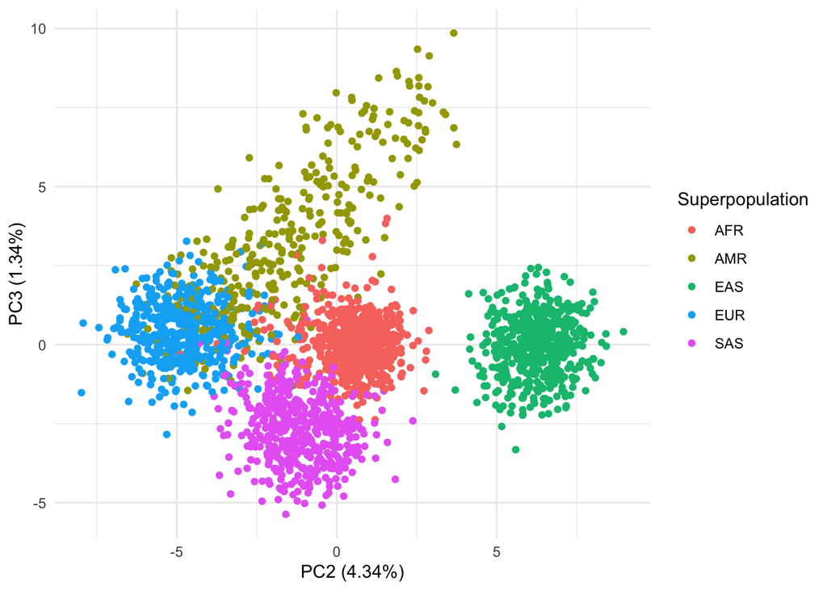

```r
ggplot(data = pca_results,
       aes(x = PC2, y = PC3, color = superpop)) +
  geom_point() +
  xlab("PC2 (4.34%)") +
  ylab("PC3 (1.34%)") +
  labs(color = "Superpopulation")
```

PC3 separates out the Admixed American and South Asian populations, which were collapsed into one group in the first PCA plot.

## **Assignment:**

### Predict unknown sample (NA21121) superpopulation using PCA

```r
gt_matrix_T_all <- all[, 7:2510] %>%
  as.matrix %>% t

pca_all <- prcomp(gt_matrix_T_all)

x_all <- pca_all$x # PCA coordinates

pca_results_all <- data.frame(sample = rownames(x_all),
                              PC1 = x_all[, 1],
                              PC2 = x_all[, 2],
                              PC3 = x_all[, 3])

pca_results_all <- merge(pca_results_all, metadata,
                         by.x = "sample", by.y = "sample")

var_explained_all <- pca_all$sdev^2 / sum(pca_all$sdev^2)
var_explained_all[1:3]
```

```
## [1] 0.09154081 0.03824824 0.01207284
```

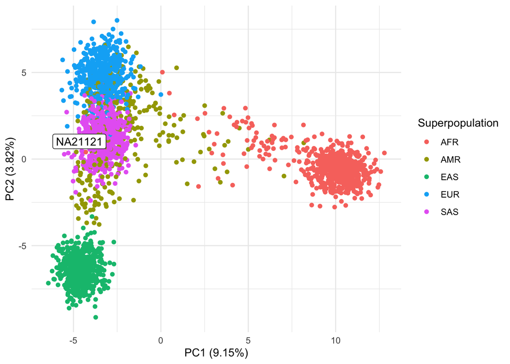

```r
unknown_T <- read.table("unknown.txt") %>%
  as.matrix %>% t

unknown_pca <- predict(pca_all,
                       unknown_T)

unknown_results <- data.frame("PC1" = unknown_pca[, "PC1"],
                              "PC2" = unknown_pca[, "PC2"],
                              "PC3" = unknown_pca[, "PC3"],
                              "sample" = "NA21121")

ggplot() +
  geom_point(data = pca_results_all,
             aes(x = PC1, y = PC2, color = superpop)) +
  geom_label(data = unknown_results,
             aes(x = PC1, y = PC2, label = sample)) +
  xlab("PC1 (9.15%)") +
  ylab("PC2 (3.82%)") +
  labs(color = "Superpopulation")
```

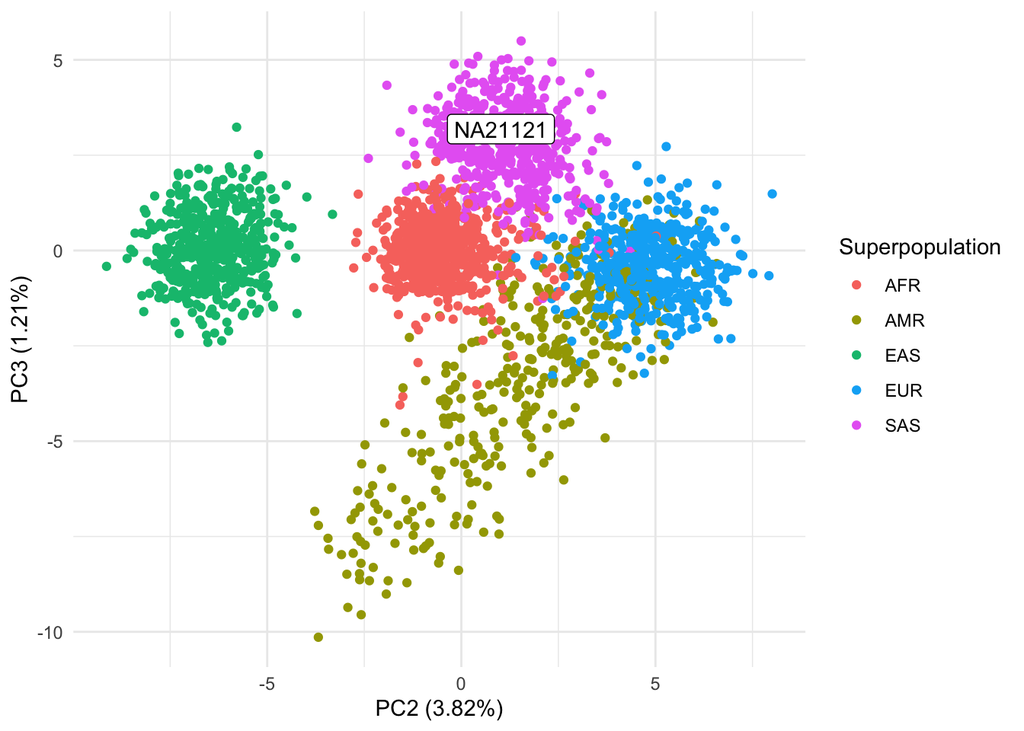

```r
ggplot() +
  geom_point(data = pca_results_all,
             aes(x = PC2, y = PC3, color = superpop)) +
  geom_label(data = unknown_results,
             aes(x = PC2, y = PC3, label = sample)) +
  xlab("PC2 (3.82%)") +
  ylab("PC3 (1.21%)") +
  labs(color = "Superpopulation")
```

`NA21121` seems to be part of the **SAS (South Asian)** superpopulation. If we look up the sample ID in the [1000 Genomes database](https://www.internationalgenome.org/), we can confirm that it’s part of the Gujarati Indians (from Houston, TX).